# MA 415/615 Project 2 Part 2: Chemical Treatment

Mar 19, 2018

## Introduction

In this project, we use the data collected from USDA QuickStats system, and clean, visualize, and explore the insight about chemical treatments applied to food crops as fertilizer, insecticides, etc. We mainly focus on the chemicals classified as RESTRICTED USE CHEMICALS and use the information of LD50 for rats of each chemical to show its toxicity. This project ends with a tidy table of toxicity measurements and data visualization analysis.

## Data Engineering - Step One

We clean the original dataset veg1.xlsx, make it to a tidy table for RESTRICTED USE CHEMICALS. We narrow down the dataset size from

```r
dim(veg.1)
```

```
## [1] 19504    21
```

to

```r
dim(a12)
```

```
## [1] 57  9
```

## Data Engineering - Step Two

According to the data table we built in step one, we build a second table to show the LD50 for rats of each restricted use chemical in it.

```r
head(LD50_4)
```

```
## # A tibble: 6 x 2
##   `Chemical Name`     `LD50 for Rats (mg/kg)`
##   <chr>                                 <dbl>
## 1 BIFENTHRIN                            54.0
## 2 CHLORANTRANILIPROLE                 5000
## 3 CHLORPYRIFOS                         202
## 4 DIAZINON                             480
## 5 DISULFOTON                             5.00
## 6 ESFENVALERATE                        246
```

## Step Two - Visualization

According to the LD50 for rats, DISULFOTON has the highes toxicity, and PRONAMIDE has the lowest. (Higher the LD50, lower the toxcity)

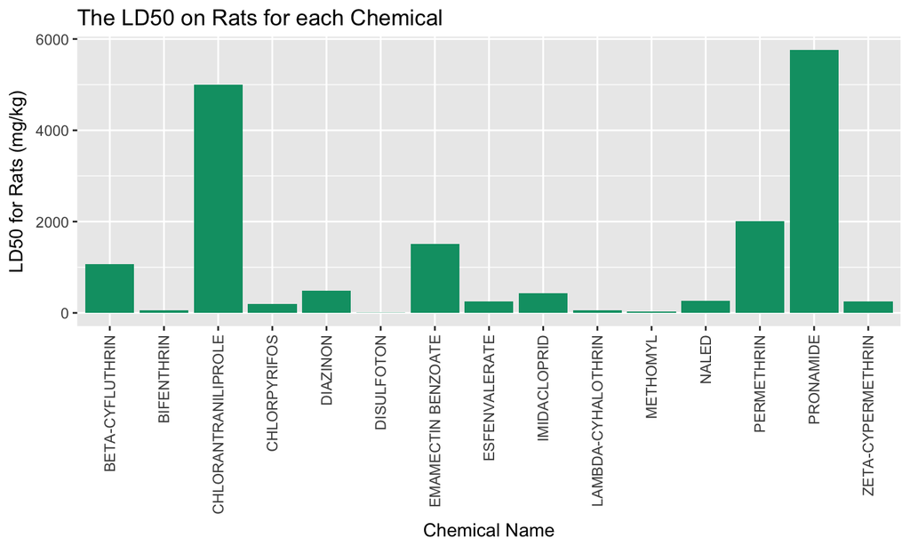

## Data Engineering - Step Three

We combine the two tables build in step one and two, and created a column to show how many rats can be killed by the amount of each chemical applied to vegetables

```r
colnames(Final_Table)
```

```
## [1] "Year"
## [2] "Commodity Name"
## [3] "Treatment Product"
## [4] "Restricted Use Chemical Name"
## [5] "Chemical Code"
## [6] "Value of the Chemical Applied to the Commodity in (LB)"
## [7] "Value of the Chemical Applied to the Commodity in (mg)"
## [8] "Chemical's LD50 for Rats (mg/kg)"
## [9] "Number of 300g Rats Can Be Killed"
```

## Chemicals Applied on BROCCOLI

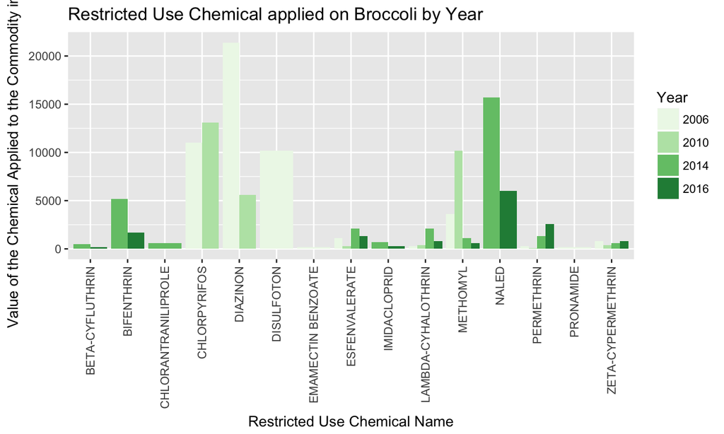

## Chemicals Applied on CAULIFLOWER

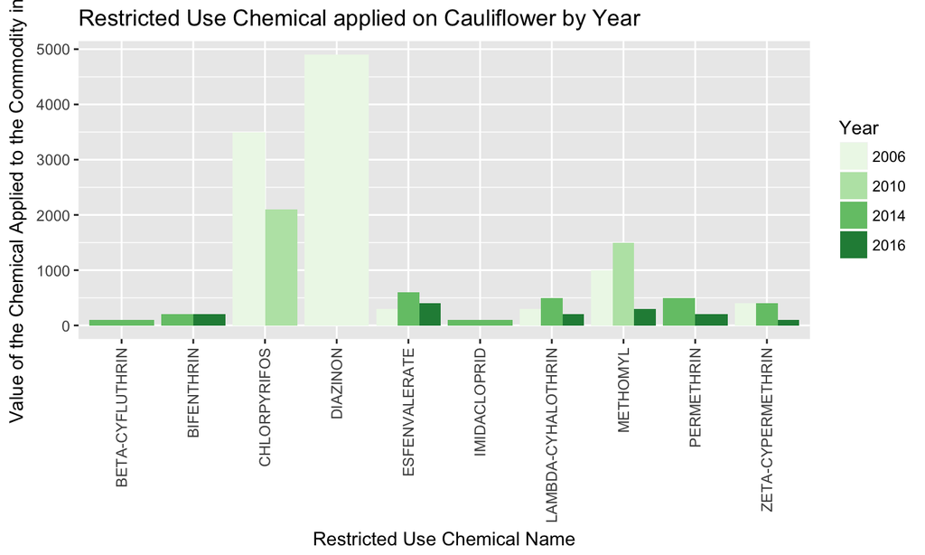

## Number of Rats can be killed, BROCCOLI, 2006

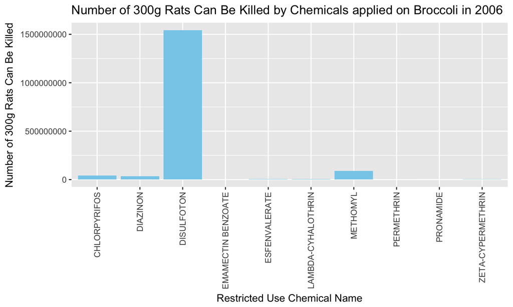

## Number of Rats can be killed, BROCCOLI, 2010

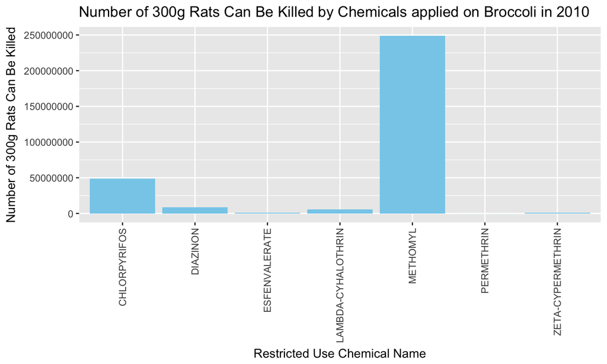

## Number of Rats can be killed, BROCCOLI, 2014

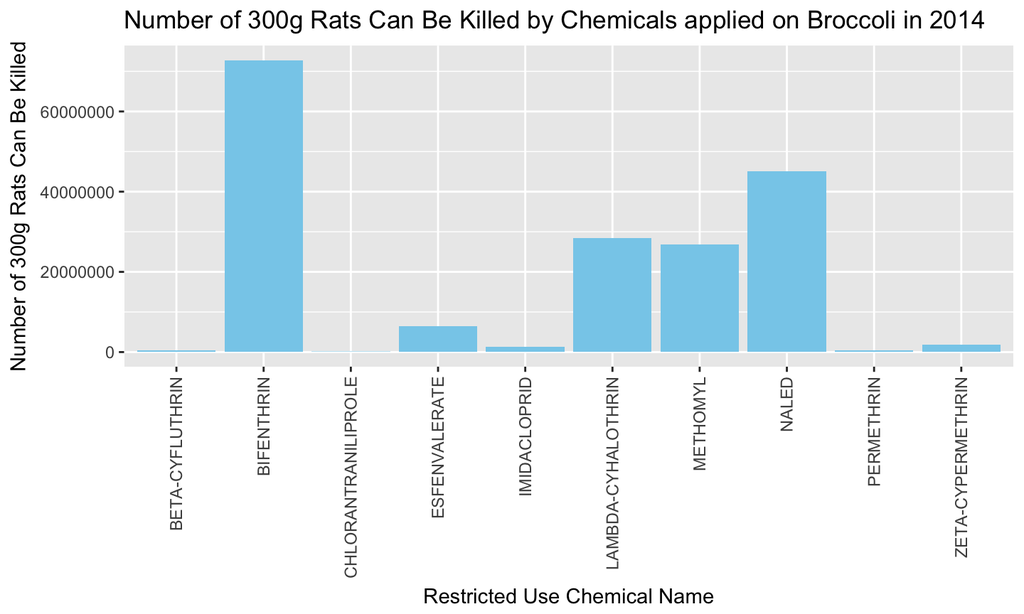

## Number of Rats can be killed, BROCCOLI, 2016

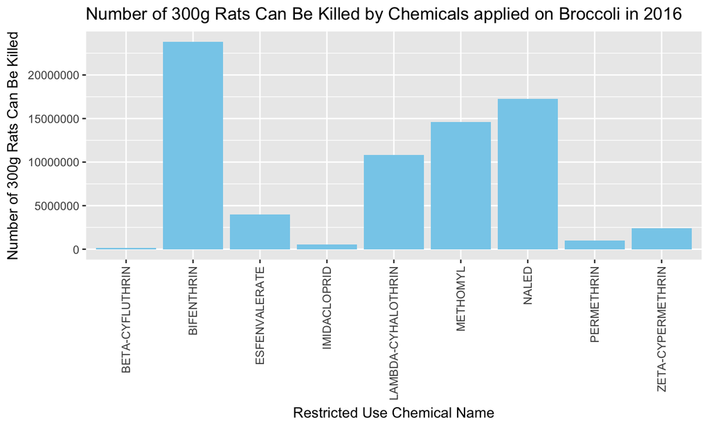

## Number of Rats can be killed, CAULIFLOWER, 2006

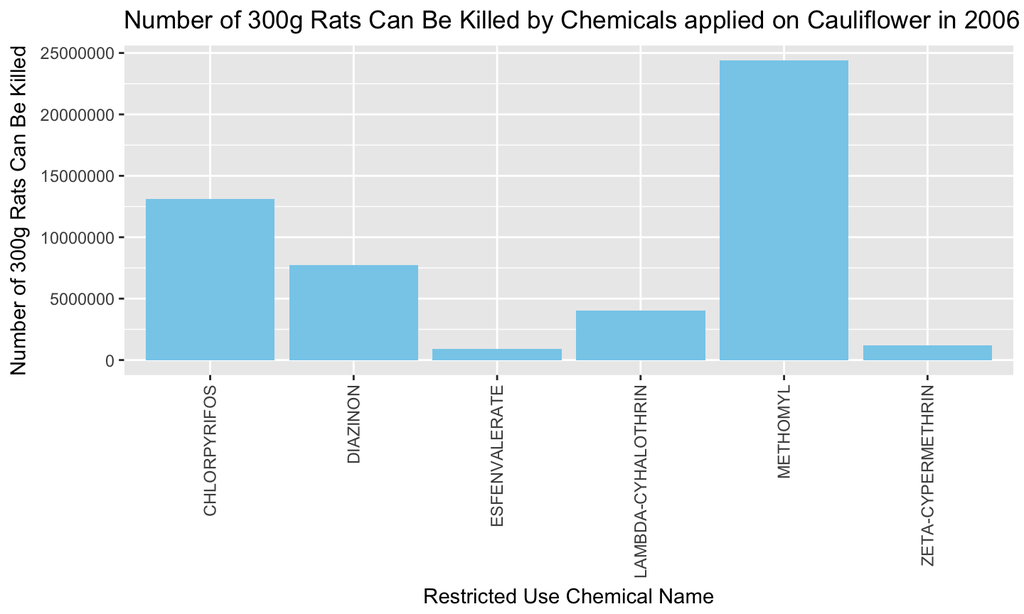

## Number of Rats can be killed, CAULIFLOWER, 2010

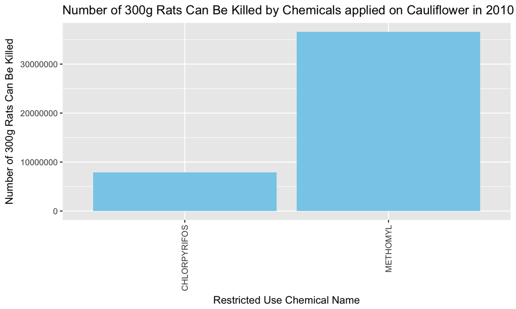

## Number of Rats can be killed, CAULIFLOWER, 2014

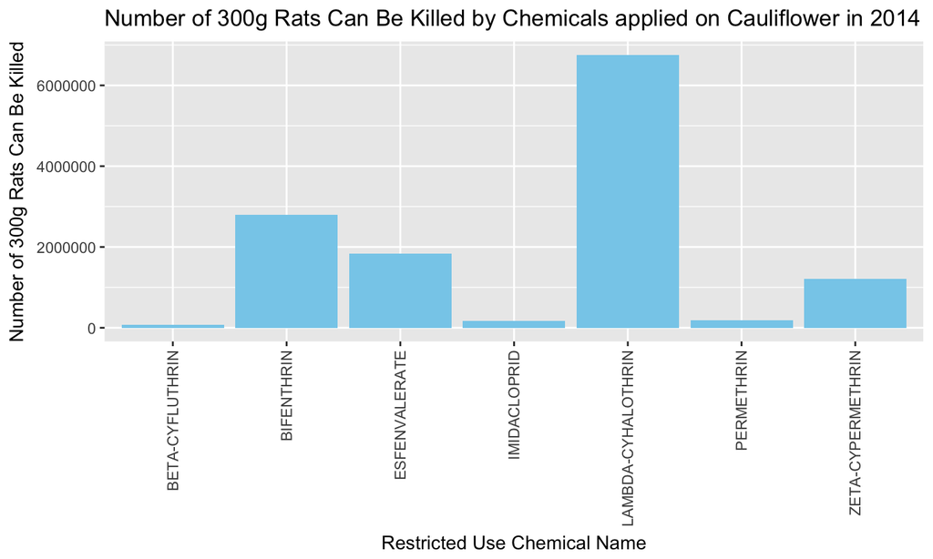

## Number of Rats can be killed, CAULIFLOWER, 2016

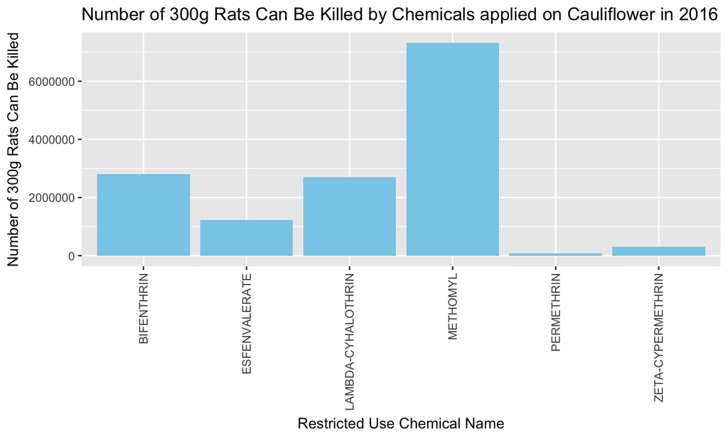